# Homework #10: Questions 1, 2, and 8.32, 8.35

## Question #1

The data below shows all home sales in Iowa City from 2005 to 2008 broken down by whether the home has central air conditioning.

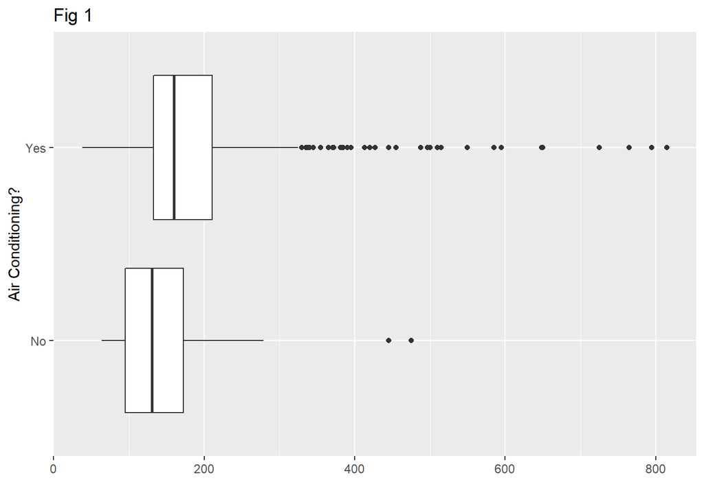

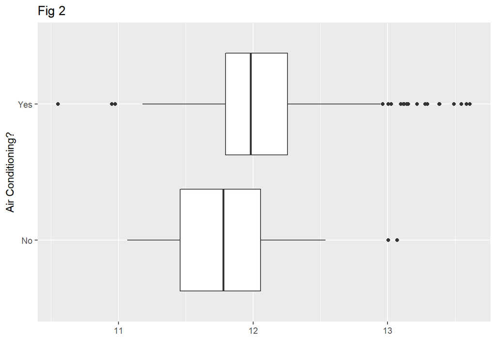

**Part A**

One of the figures shown above depicts the sale prices on the log scale, while the other does not. Which do you believe displays the transformed data?

**Part B**

The most expensive home sold for 815,000 dollars; if we were to conduct a two-sample t-test comparing the sale prices of homes with and without AC, would you expect the $p$-value to be larger or smaller if we excluded this outlier.

**Part C**

Would it be prudent to omit the outlier mentioned in part B?

**Part D**

The mean of the **log-transformed sale prices** of homes with AC is 12.03, while the mean for homes without AC is 11.80. The standard deviation (again for the log-transformed prices) is 0.39 for homes with AC and 0.40 for homes without AC. There were 703 homes with AC and 74 homes without in AC in the data. Use this information to construct a 95% confidence interval for the **relative increase in price** for homes with AC compared to homes without AC, provide an interpretation of your interval.

## Question #2

The figure below depicts the tumor size of 199 women with breast cancer in a particular study

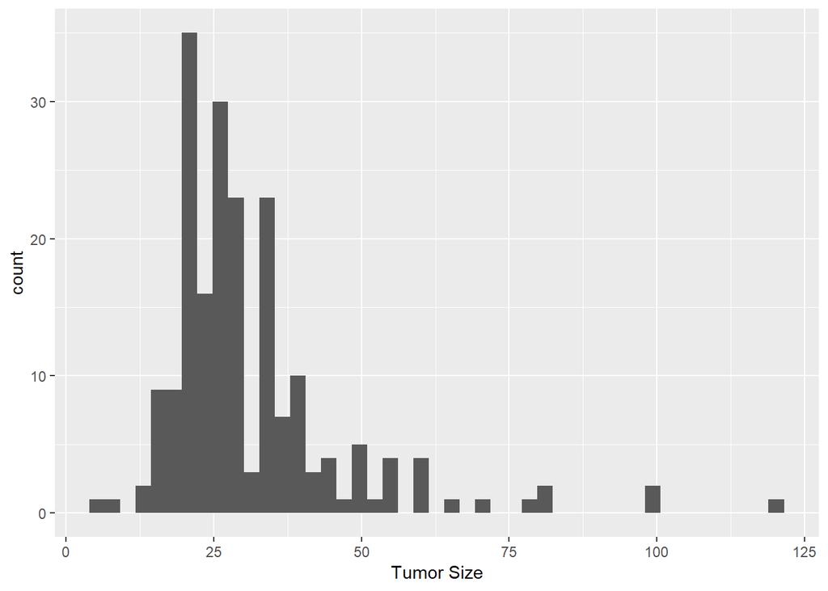

**Part A**

Describe the distribution of tumor size. Do you think a log-transformation should be used on these data?

**Part B**

In this study, some of the women were pre-menopause while others were post-menopause. The 95% confidence interval for the mean difference in tumor size (pre-menopause - post-menopause) is (-6.48, 2.68). Provide a one-sentence interpretation of this interval. Is it plausible that the two groups, on average, have the same tumor size? Explain.

**Part C**

After applying the log-transformation we perform the same computer procedure on the new variable: log(tumor size). The software output indicates the 95% confidence interval for the difference in means of this variable (pre-menopause - post-menopause) is (-0.17, 0.08). Use this information to provide a relative comparison of tumor size for these groups. Is it plausible that the two groups, on average have the same tumor size? Explain.

**Part D**

The software used to find the confidence intervals in Part B and Part C also performs hypothesis testing. Which test, Part B or Part C, do you think had the smaller $p$-value?

## From the Textbook:

8.32 and 8.35